# Housing Price Prediction Using Multiple Regression

**Author:** Hunter Brashears  
**Tools:** R, Jupyter Notebook  
**Techniques:** Multiple Linear Regression, Interaction Effects, Quadratic Regression, Model Diagnostics

## Project Overview

This project analyzes the relationship between house price and common property attributes while demonstrating how regression modeling can support data-driven pricing decisions in real estate.

## Important Variables in the Analysis

| Variable | What does it represent? |
| --- | --- |
| price | Sale price of the home |
| bedrooms | Number of bedrooms |
| bathrooms | Number of bathrooms |
| sqft_living | Size of the living area in sqft |
| sqft_above | Size of the upper level in sqft |
| sqft_lot | Size of the lot in sqft |
| age | Age of the home |
| grade | Measure of craftsmanship and the quality of materials used to build the home |
| appliance_age | Average age of all appliances in the home |
| crime | Crime rate per 100,000 people |
| backyard | Home has a backyard (backyard=1) or not (backyard=0) |
| school_rating | Average rating of schools in the area |
| view | Home backs out to a lake (view=2), backs out to trees (view=1), or backs out to a road (view=0) |

## Approach

1. Load and clean the data
2. Perform exploratory analysis (EDA)
3. Fit a baseline multiple regression model (Model 1)
4. Fit an interaction model (Model 2) to test whether relationships vary by neighborhood conditions
5. Create quadratic model (Model 3) to test non linear relationships
6. Compare models using adjusted R², residual standard error and nested F-test.
7. Use diagnostic plots to validate model assumptions and support final model.

## Load Data

```r
# upload housing_v2.csv
housing <- read.csv(file="housing_v2.csv", header=TRUE, sep=",")

# converting appropriate variables to factors
housing <- within(housing, {
   view <- factor(view)
   backyard <- factor(backyard)
})

# number of rows & columns
dim(housing)
```

1. 2692

2. 23

```r
# check for missing values
colSums(is.na(housing))
```

**id**

0

**price**

0

**bedrooms**

0

**bathrooms**

0

**sqft_living**

0

**sqft_lot**

0

**floors**

0

**backyard**

0

**view**

0

**condition**

0

**grade**

0

**sqft_above**

0

**sqft_basement**

0

**yr_built**

0

**yr_renovated**

0

**renovated**

0

**zipcode**

0

**sqft_living15**

0

**sqft_lot15**

0

**age**

0

**appliance_age**

0

**crime**

0

**school_rating**

0

## EDA

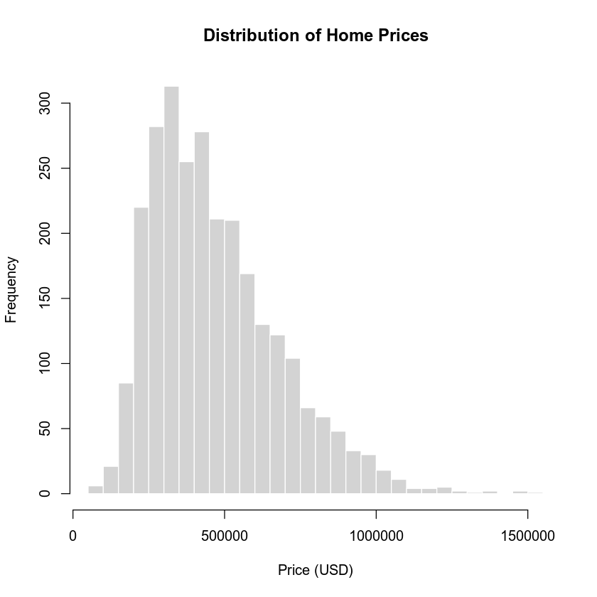

```r
hist(housing$price,
     breaks = 40,
     main = "Distribution of Home Prices",
     xlab = "Price (USD)",
     col = "lightgray",
     border = "white")
```

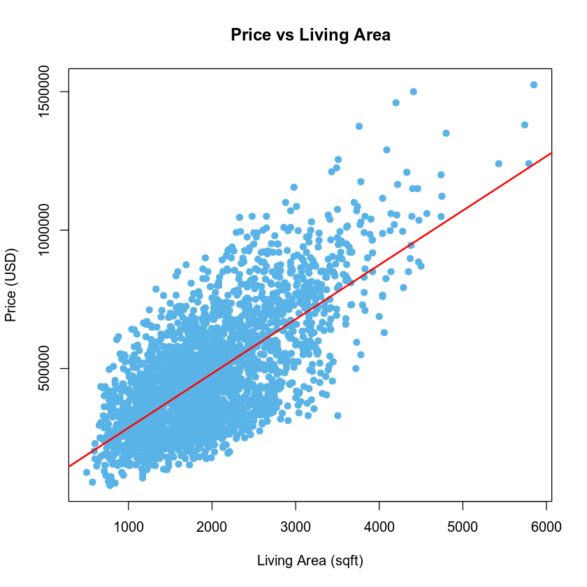

```r
# Plot a graph to see how living area affects housing price
plot(housing$sqft_living, housing$price,
     main = "Price vs Living Area",
     xlab = "Living Area (sqft)",
     ylab = "Price (USD)",
     pch = 19,
     col = rgb(0.35, 0.70, 0.90))

# Add linear linear trend line
abline(lm(price ~ sqft_living, data = housing), col = "red", lwd = 2)
```

## Modeling

### Evaluation Criteria

Models are evaluated using:

- Adjusted R²
- Residual Standard Error
- Statistical significance of predictors

## Model 1 — Baseline Multiple Regression

This model estimates home price using key variables sqare footage, square footage of upper living area, age of the house, number of bathrooms, and the view (home backs out to a lake (view=2), backs out to trees (view=1), or backs out to a road (view=0)). It serves as a reference point for more complex models.

```r
model1 <- lm(price ~ sqft_living + sqft_above + age + bathrooms + view,
             data = housing)

summary(model1)
```

```
Call:
lm(formula = price ~ sqft_living + sqft_above + age + bathrooms +
    view, data = housing)

Residuals:
    Min      1Q  Median      3Q     Max
-419299 -101792   -5606   93896  489323

Coefficients:
             Estimate Std. Error t value Pr(>|t|)
(Intercept) 7.709e+03  1.411e+04   0.546  0.58495
sqft_living 1.293e+02  8.123e+00  15.916  < 2e-16 ***
sqft_above  1.951e+01  7.458e+00   2.616  0.00894 **
age         1.451e+03  1.199e+02  12.098  < 2e-16 ***
bathrooms   4.397e+04  6.126e+03   7.178 9.13e-13 ***
view1       1.675e+05  1.071e+04  15.640  < 2e-16 ***
view2       2.490e+05  1.201e+04  20.739  < 2e-16 ***
---
Signif. codes:  0 '***' 0.001 '**' 0.01 '*' 0.05 '.' 0.1 ' ' 1

Residual standard error: 133600 on 2685 degrees of freedom
Multiple R-squared:  0.6029,	Adjusted R-squared:  0.602
F-statistic: 679.3 on 6 and 2685 DF,  p-value: < 2.2e-16
```

### Model 1 Interpretation

- **sqft_living** and **bathrooms** have positive realtionships with home price, indicating that larger homes and additional bathrooms increase value.
- **age** shows a positive association with price in this dataset, suggesting that older homes may be located in more desirable or established neighborhoods.
- **view** coefficients represent price differences relative to the baseline view category.

## Model 2 — Interaction Between School Rating and Crime

This model tests whether the effect of school rating on home price depends on neighborhood crime levels.

```r
model2 <- lm(price ~ sqft_living + sqft_above + age + bathrooms + view +
                       school_rating * crime,
             data = housing)

summary(model2)
```

```
Call:
lm(formula = price ~ sqft_living + sqft_above + age + bathrooms +
    view + school_rating * crime, data = housing)

Residuals:
    Min      1Q  Median      3Q     Max
-299469  -55604     247   53566  338047

Coefficients:
                      Estimate Std. Error t value Pr(>|t|)
(Intercept)         -3.184e+05  2.372e+04 -13.423  < 2e-16 ***
sqft_living          4.696e+01  5.080e+00   9.244  < 2e-16 ***
sqft_above           9.206e+00  4.533e+00   2.031   0.0424 *
age                  5.785e+02  7.384e+01   7.834 6.74e-15 ***
bathrooms            2.074e+04  3.738e+03   5.549 3.16e-08 ***
view1                6.216e+04  6.742e+03   9.220  < 2e-16 ***
view2                1.215e+05  7.685e+03  15.812  < 2e-16 ***
school_rating        1.096e+05  3.069e+03  35.705  < 2e-16 ***
crime                1.251e+03  1.166e+02  10.730  < 2e-16 ***
school_rating:crime -3.686e+02  1.670e+01 -22.076  < 2e-16 ***
---
Signif. codes:  0 '***' 0.001 '**' 0.01 '*' 0.05 '.' 0.1 ' ' 1

Residual standard error: 81010 on 2682 degrees of freedom
Multiple R-squared:  0.8542,	Adjusted R-squared:  0.8537
F-statistic:  1745 on 9 and 2682 DF,  p-value: < 2.2e-16
```

```r
# Compare fit statistics
print("R-squared values")
summary(model1)$adj.r.squared
summary(model2)$adj.r.squared

print("Residual Standard Error")
summary(model1)$sigma
summary(model2)$sigma

# Nested F-test to see if model 2 statistically imrpoves from model 1
anova(model1, model2)
```

```
[1] "R-squared values"
```

0.601967422715619

0.853668565907928

```
[1] "Residual Standard Error"
```

133604.803036098

81008.6838416668

A anova: 2 × 6

| Res.Df <dbl> | RSS <dbl> | Df <dbl> | Sum of Sq <dbl> | F <dbl> | Pr(>F) <dbl> |
| --- | --- | --- | --- | --- | --- |
| 2685 | 4.792790e+13 | NA | NA | NA | NA |
| 2682 | 1.760038e+13 | 3 | 3.032753e+13 | 1540.468 | 0 |

### Model 2 Interpretation

- **school_rating** measures the effect of school quality when crime is zero.
- **crime** measures the effect of crime when school rating is zero.
- The **interaction term** shows how the impact of school rating changes as crime increases.

A negative interaction term indicates that the positive effect of school rating on price is reduced in higher-crime areas.

## Results so far

**Model 1** established a baseline relationship between price and core housing features.  
**Model 2** added an interaction effect to test whether neighborhood conditions (crime) change the influence of school rating on price.

Next, I test whether nonlinear (curved) relationships improve performance and then confirm model assumptions using diagnostics.

## Model 3 — Nonlinear (Quadratic) Effects

This model tests whether the effect of key predictors is nonlinear by adding squared terms. This can capture diminishing returns or acceleration effects.

```r
model3 <- lm(price ~ sqft_living + I(sqft_living^2) +
                     sqft_above + age + I(age^2) +
                     bathrooms + view +
                     school_rating * crime,
             data = housing)

summary(model3)
```

```
Call:
lm(formula = price ~ sqft_living + I(sqft_living^2) + sqft_above +
    age + I(age^2) + bathrooms + view + school_rating * crime,
    data = housing)

Residuals:
    Min      1Q  Median      3Q     Max
-281936  -55715     313   52221  312727

Coefficients:
                      Estimate Std. Error t value Pr(>|t|)
(Intercept)         -2.388e+05  2.691e+04  -8.874  < 2e-16 ***
sqft_living          2.004e+00  1.025e+01   0.196   0.8450
I(sqft_living^2)     1.087e-02  1.983e-03   5.481 4.62e-08 ***
sqft_above           3.598e+00  4.669e+00   0.771   0.4410
age                  1.446e+02  2.191e+02   0.660   0.5094
I(age^2)             4.066e+00  1.898e+00   2.142   0.0323 *
bathrooms            2.217e+04  3.887e+03   5.702 1.31e-08 ***
view1                6.029e+04  6.713e+03   8.981  < 2e-16 ***
view2                1.144e+05  7.771e+03  14.725  < 2e-16 ***
school_rating        1.062e+05  3.101e+03  34.233  < 2e-16 ***
crime                1.097e+03  1.193e+02   9.200  < 2e-16 ***
school_rating:crime -3.457e+02  1.708e+01 -20.241  < 2e-16 ***
---
Signif. codes:  0 '***' 0.001 '**' 0.01 '*' 0.05 '.' 0.1 ' ' 1

Residual standard error: 80480 on 2680 degrees of freedom
Multiple R-squared:  0.8562,	Adjusted R-squared:  0.8556
F-statistic:  1450 on 11 and 2680 DF,  p-value: < 2.2e-16
```

```r
# Compare adjusted R^2 (variance in price explained by model)
print("R-squared values")
summary(model2)$adj.r.squared
summary(model3)$adj.r.squared

# Compare residual standard error (typical error in dollars)
print("Residual Standard Error")
summary(model2)$sigma
summary(model3)$sigma

# Nested F-test: does Model 3 significantly improve Model 2?
anova(model2, model3)
```

```
[1] "R-squared values"
```

0.853668565907928

0.855581424938599

```
[1] "Residual Standard Error"
```

81008.6838416668

80477.4653176816

A anova: 2 × 6

| Res.Df <dbl> | RSS <dbl> | Df <dbl> | Sum of Sq <dbl> | F <dbl> | Pr(>F) <dbl> |
| --- | --- | --- | --- | --- | --- |
| 2682 | 1.760038e+13 | NA | NA | NA | NA |
| 2680 | 1.735735e+13 | 2 | 243027096301 | 18.76187 | 8.097284e-09 |

## Final Model Selection

I select model 3 based on:

- Higher adjusted R²
- Lower residual standard error
- Significant improvement shown by nested F-tests

```r
final_model <- model3
```

## Model Validation

Linear regression relies on assumptions about residual behavior.  
Below I evaluate whether those assumptions are reasonably satisfied for the final model.

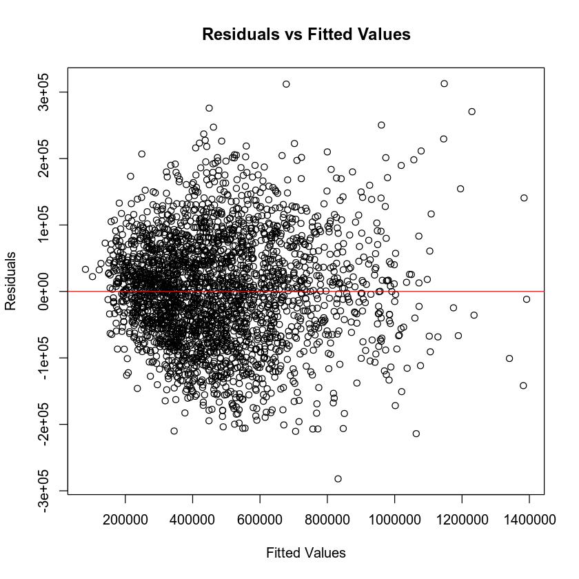

```r
# Residuals vs fitted values
plot(fitted(final_model), residuals(final_model),
     xlab = "Fitted Values",
     ylab = "Residuals",
     main = "Residuals vs Fitted Values")
abline(h = 0, col = "red")
```

The residuals appear randomly scattered around zero which suggests that the linearity assumption is satisfied. Some increase in variance is observed at higher fitted values, which is common in housing price data.

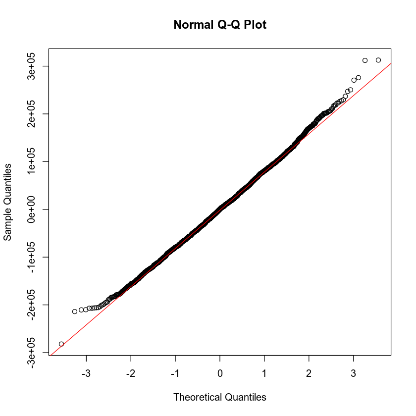

```r
# Normal Q-Q plot
qqnorm(residuals(final_model))
qqline(residuals(final_model), col = "red")
```

The Q–Q plot indicates that residuals are approximately normally distributed, with mild deviations in the tails.

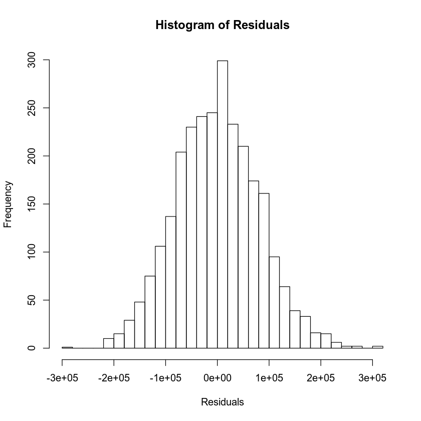

```r
# Histogram of residuals
hist(residuals(final_model),
     main = "Histogram of Residuals",
     xlab = "Residuals",
     breaks = 30)
```

The histogram of residuals is approximately symmetric and centered around zero, further supporting the normality assumption.

## Model Performance Summary

The final regression model explains approximately 86% of the variation in housing prices and achieves a residual standard error of $80,000 indicating the typical prediction error when estimating home prices using this model. The model validation indicates that key regression assumptions are reasonably satisfied. The nonlinear vairbales added statistically improved model performance.

# Conclusion